# Analysis Code

Lorenzo Ricolfi

# Packages

The following packages are required to run the code in this script.

```r
#devtools::install_github("EIvimeyCook/ShinyDigitise")
#library(shinyDigitise)
pacman::p_load(tidyr,
               dplyr,
               here,
               ggplot2,
               gridExtra,
               metafor,
               orchaRd,
               stringr
               )
```

```r
ma_details <- read.csv(here("data/ma_details.csv"))
ma_e_details <- read.csv(here("data/ma_e_details.csv"))
```

# Data wrangling and cleaning

```r
ma_e_details <- ma_e_details %>%
  filter(chemical_class == "PFAS",
         !is.na(health_outcome_type),
         ma_es_measure != "unclear",
         !ma_id %in% c("ma_048", "ma_056", "ma_064")) %>%
  mutate(ma_es_measure = recode(
    ma_es_measure,
    "? (regression coefficient) value" = "Beta (regression coefficient) value",
    "beta (regression coefficient) value" = "Beta (regression coefficient) value",
    "Adjusted ? (regression coefficient)" = "Beta (regression coefficient) value",
    "adjusted coefficient regression (?)" = "Beta (regression coefficient) value",
    "relative risk" = "Risk ratio",
    "RR (risk ratio)" = "Risk ratio",
    "OR (odds ratio)" = "Odds ratio",
    "fishers z" = "Fisher's Z",
    "log OR (odds ratio)" = "log Odds ratio")) %>%
  mutate(chemical_id = recode(
    chemical_id,
    "n-PFOA" = "PFOA",
    "n-PFOS" = "PFOS",
    "PFHsX" = "PFHxS")) %>%
  left_join(ma_details, by = "ma_id")
```

# Exploratory analyses

## Effect size types

```r
es_count <- ma_e_details %>%
  filter(!is.na(ma_es_measure) & ma_es_measure != "") %>%
  group_by(ma_es_measure) %>%
  summarise(n_meta_analyses = n_distinct(ma_id),
            n_chemical_groups = n_distinct(chemical_class),
            n_health_outcomes = n_distinct(health_outcome_type),
            n_health_groups = n_distinct(health_outcome_group),
            n_non_na_point_estimates = sum(!is.na(ma_point_estimate))) %>%
  arrange(desc(n_meta_analyses)) %>%
  head(20)
# Convert the table to a grid for plotting
es_table <- tableGrob(es_count)
```

```r
# Save the table as an image
ggsave(here("figs/exploratory_analysis/es_table.png"), es_table, width = 12, height = 7)
```

## Chemical ID

```r
# Count the number of occurrences of each chemical_id
chemical_count <- ma_e_details %>%
  filter(!is.na(chemical_id) & chemical_id != "") %>%
  group_by(chemical_id) %>%
  summarise(n_meta_analyses = n_distinct(ma_id),
            n_health_outcomes = n_distinct(health_outcome_type),
            n_health_outcome_group = n_distinct(health_outcome_group),
            n_non_na_point_estimates = sum(!is.na(ma_point_estimate))) %>%
  arrange(desc(n_meta_analyses)) %>%
  head(20)
# Convert the table to a grid for plotting
chem_table <- tableGrob(chemical_count)
```

```r
# Save the table as an image
ggsave(here("figs/exploratory_analysis/chemicals_table.png"), chem_table, width = 11, height = 7)
```

## Health outcomes

```r
# Fix encoding issues in health_outcome_type
ma_e_details$health_outcome_type <- iconv(ma_e_details$health_outcome_type, from = "UTF-8", to = "UTF-8", sub = "")

# Count the number of occurrences of each health_outcome_type
outcome_type_table <- ma_e_details %>%
  filter(!is.na(health_outcome_type) & health_outcome_type != "") %>%
  group_by(health_outcome_type) %>%
  summarise(n_meta_analyses = n_distinct(ma_id),
            n_health_outcomes = n_distinct(health_outcome_type),
            n_non_na_point_estimates = sum(!is.na(ma_point_estimate)),
            n_non_na_point_estimates = sum(!is.na(ma_point_estimate))) %>%
  arrange(desc(n_meta_analyses)) %>%
  head(20)

# Convert the table to a grid for plotting
ho_table <- tableGrob(outcome_type_table)
```

```r
# Save the table as an image
ggsave(here("figs/exploratory_analysis/health_outcome_type_table.png"), ho_table, width = 11, height = 6)
```

## Health outcome group

```r
# Count the number of occurrences of each health_outcome_info
outcome_group_table <- ma_e_details %>%
  filter(!is.na(health_outcome_group) & health_outcome_group != "") %>%
  group_by(health_outcome_group) %>%
  summarise(n_meta_analyses = n_distinct(ma_id),
            n_health_outcome_types = n_distinct(health_outcome_type),
            n_non_na_point_estimates = sum(!is.na(ma_point_estimate))) %>%
  arrange(desc(n_meta_analyses)) %>%
  head(8)

# Convert the table to a grid for plotting
ho_group_table <- tableGrob(outcome_group_table)
```

```r
# Save the table as an image
ggsave(here("figs/exploratory_analysis/health_outcome_group_table.png"), ho_group_table, width = 12, height = 5)
```

# Effect size conversion

See: Borenstein, M., Hedges, L. V., Higgins, J. P., & Rothstein, H. R. (2021). Introduction to meta-analysis. John wiley & sons.

```r
# Define a conversion function with an optional baseline risk parameter
convert_to_logOR <- function(effect_measure, point_estimate, ma_l_ci, ma_u_ci, regression_type = NA, baseline_risk = NA) {
  # Ensure the effect measure is treated as character
  effect_measure <- as.character(effect_measure)
  # Ensure point estimate, lower CI, and upper CI are numeric
  point_estimate <- suppressWarnings(as.numeric(as.character(point_estimate)))
  ma_l_ci <- suppressWarnings(as.numeric(as.character(ma_l_ci)))
  ma_u_ci <- suppressWarnings(as.numeric(as.character(ma_u_ci)))

  # Conversion for Odds ratio and log Odds ratio
  if (effect_measure == "Odds ratio") {
    # Convert OR to logOR
    return(c(log(point_estimate), log(ma_l_ci), log(ma_u_ci)))

  } else if (effect_measure == "log Odds ratio") {
    # Already in logOR
    return(c(point_estimate, ma_l_ci, ma_u_ci))

    # Conversion for SMD (standardized mean difference)
  } else if (effect_measure == "SMD (standardized mean difference)") {
    # Following Borenstein et al. (2021): logOR = SMD * pi/sqrt(3)
    logOR_point_estimate <- point_estimate * (pi / sqrt(3))

    # Convert lower and upper confidence intervals using the same logic
    logOR_l_ci <- ma_l_ci * (pi / sqrt(3))
    logOR_u_ci <- ma_u_ci * (pi / sqrt(3))

    return(c(logOR_point_estimate, logOR_l_ci, logOR_u_ci))

    # Conversion for Relative risk / Risk ratio with optional baseline risk
  } else if (effect_measure == "Risk ratio") {
    if (!is.na(baseline_risk)) {
      # Using the conversion: OR = RR * (1-p0) / (1-RR*p0)
      OR <- point_estimate * (1 - baseline_risk) / (1 - point_estimate * baseline_risk)
      OR_l_ci <- ma_l_ci * (1 - baseline_risk) / (1 - ma_l_ci * baseline_risk)
      OR_u_ci <- ma_u_ci * (1 - baseline_risk) / (1 - ma_u_ci * baseline_risk)
      return(c(log(OR), log(OR_l_ci), log(OR_u_ci)))
    } else {
      # If no baseline risk is provided, fallback to the approximation:
      return(c(log(point_estimate), log(ma_l_ci), log(ma_u_ci)))
    }

    # Conversion for Fisher's z (often used for correlations)
  } else if (grepl("fishers z", effect_measure, ignore.case = TRUE)) {
    # Convert z to correlation, then to logOR.
    # r = tanh(z)
    # Approximation: logOR = r * pi/sqrt(3)
    r <- tanh(point_estimate)
    return(r * (pi / sqrt(3)))

    # Conversion for regression coefficients assumed from logistic regression:
  } else if (effect_measure %in% c("Beta (regression coefficient) value")) {
    # Check if regression_type is 'logistic'
    if (!is.na(regression_type) && regression_type == "logistic") {
        return(c(point_estimate, ma_l_ci, ma_u_ci))
    } else {
        return(rep(NA, 3)) # Not logistic regression, cannot convert
    }
} else {
    warning("Effect measure conversion not implemented for: ", effect_measure)
    return(rep(NA, 3)) # Return NA for all three
  }
}
```

# Effect size calculation

```r
# Apply conversion to each row
ma_e_details <- ma_e_details %>%
  rowwise() %>%
  mutate(
    converted = list(convert_to_logOR(ma_es_measure, ma_point_estimate,
                                     ma_l_ci, ma_u_ci, regression_type, 0.1)),
    logOR = converted[1],
    l_ci_logOR = converted[2],
    u_ci_logOR = converted[3]
  ) %>%
  ungroup() %>%
  select(-converted) %>%
  filter(!is.na(logOR))
```

# First Research Question

## Overall Model

```r
# Calculating effect size standard errors
# SE = (Upper bound – Lower bound) / (2 × 1.96)
ma_e_details <- ma_e_details %>%
  mutate(se = ((u_ci_logOR - l_ci_logOR)/(2*1.96)))  # Convert 95% CI to standard error (se)

# Fitting the multilevel meta-analytic model
mod <- rma.mv(yi = logOR,  # Effect size
              V = se^2, # Variance
              random = list(~1|ma_id, # Meta-analysis identity
                            ~1|ma_e_id), # Meta-analytic point estimate identity
              data = ma_e_details)
# Display model results
summary(mod)
```

```
##
## Multivariate Meta-Analysis Model (k = 277; method: REML)
##
##    logLik   Deviance        AIC        BIC       AICc
##  130.5521  -261.1042  -255.1042  -244.2430  -255.0160
##
## Variance Components:
##
##             estim    sqrt  nlvls  fixed   factor
## sigma^2.1  0.0081  0.0898     30     no    ma_id
## sigma^2.2  0.0040  0.0631    277     no  ma_e_id
##
## Test for Heterogeneity:
## Q(df = 276) = 1683.7782, p-val < .0001
##
## Model Results:
##
## estimate      se    zval    pval   ci.lb   ci.ub
##   0.0373  0.0186  2.0086  0.0446  0.0009  0.0737  *
##
## ---
## Signif. codes:  0 '***' 0.001 '**' 0.01 '*' 0.05 '.' 0.1 ' ' 1
```

```r
# I²
i2_results <- i2_ml(mod)
print(i2_results)
```

```
##   I2_Total   I2_ma_id I2_ma_e_id
##   99.99561   66.93282   33.06279
```

```r
# Print I² values
cat("I² (between studies):", round(i2_results["I2_ma_id"], 1), "%\n")
```

```
## I² (between studies): 66.9 %
```

```r
cat("I² (within studies):", round(i2_results["I2_ma_e_id"], 1), "%\n")
```

```
## I² (within studies): 33.1 %
```

## Forest plot

```r
ma_e_details$ma_e_id <- factor(ma_e_details$ma_e_id)
# Reorder ma_e_id levels by logOR (descending), excluding "Overall"
ma_e_details$ma_e_id <- factor(
  ma_e_details$ma_e_id,
  levels = c(
    levels(ma_e_details$ma_e_id)[order(ma_e_details$logOR, decreasing = TRUE)],
    "Overall"  # Ensure "Overall" is last
  )
)

ggplot(ma_e_details, aes(x = logOR, y = ma_e_id)) +
  geom_point(shape = 18, size = 4) +  # Point estimates
  geom_errorbarh(aes(xmin = l_ci_logOR, xmax = u_ci_logOR),
                 height = 0.2) +      # Confidence intervals
  geom_vline(xintercept = 0,           # Line at null effect
             linetype = "dashed",
             color = "red") +
  geom_point(data = data.frame(logOR = mod$b[1],
                              ma_e_id = "Overall",
                              l_ci_logOR = mod$ci.lb,
                              u_ci_logOR = mod$ci.ub),
             shape = 23, size = 4, fill = "red") +
  geom_errorbarh(data = data.frame(logOR = mod$b[1], ma_e_id = "Overall"),
                 aes(xmin = mod$ci.lb, xmax = mod$ci.ub),
                 height = 0.3, size = 1) +
  labs(x = "log Odds Ratio",
       y = "Meta-analysis",
       title = "Forest Plot of Effect Sizes") +
  theme_minimal() +
  theme(panel.grid.major.y = element_blank()) + # Cleaner horizontal lines
  scale_y_discrete(limits = rev)
```

[output not shown]

More elaborated forest plot:

```r
# Step 1 & 2: Get first point for each ma_id
labels_df <- ma_e_details %>%
    group_by(ma_id) %>%
    slice(1) %>%
    ungroup()

# Step 3: Add geom_text to your plot
ggplot(ma_e_details, aes(x = logOR, y = ma_e_id, color = ma_id)) +
    geom_point(shape = 18, size = 4) +
    geom_errorbarh(aes(xmin = l_ci_logOR, xmax = u_ci_logOR), height = 0.2) +
    geom_vline(xintercept = 0, linetype = "dashed", color = "red") +
    geom_point(data = data.frame(logOR = mod$b[1],
                                 ma_e_id = "Overall",
                                 l_ci_logOR = mod$ci.lb,
                                 u_ci_logOR = mod$ci.ub),
               aes(x = logOR, y = ma_e_id),  # explicitly declare aes
               shape = 23, size = 4, fill = "red", color = "black", inherit.aes = FALSE) +
    geom_errorbarh(data = data.frame(logOR = mod$b[1], ma_e_id = "Overall"),
                   aes(xmin = mod$ci.lb, xmax = mod$ci.ub, y = ma_e_id),
                   height = 0.3, size = 1, inherit.aes = FALSE) +
    # geom_text for labels
    geom_text(data = labels_df,
              aes(x = 1, y = ma_e_id, label = ma_id),  # fixed x value
              hjust = 0,  # left-aligned
              size = 3,
              inherit.aes = FALSE) +
    labs(x = "log Odds Ratio",
         y = "Meta-analysis",
         title = "Forest Plot of Effect Sizes",
         color = "Meta-analysis ID") +
    theme_minimal() +
    theme(panel.grid.major.y = element_blank()) +
  scale_y_discrete(limits = rev(levels(factor(ma_e_details$ma_e_id))))
```

[output not shown]

## OrchaRd

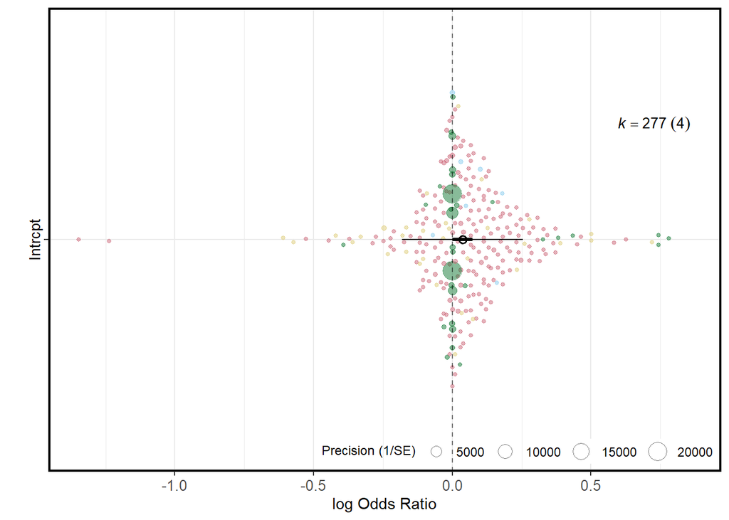

```r
# Create orchard plot
orchard_plot <- orchard_plot(
  object = mod,
  mod = "1",
  group = "ma_es_measure",
  xlab = "log Odds Ratio",
  colour  = TRUE,
  transfm = "none"
) +
  theme(
    panel.border = element_rect(colour = "black", fill = NA, size = 1.3),
    axis.text.x = element_text(size = 10)
  )
# Display the plot
print(orchard_plot)
```

```r
extreme_logOR <- ma_e_details %>% filter(logOR < -0.5 | logOR > 0.5)
zero_logOR <- ma_e_details %>% filter(logOR == 0)
```

# Impact of effect size metric

```r
ma_e_details$ma_es_measure <- as.factor(ma_e_details$ma_es_measure)
ma_e_details$ma_es_measure <- relevel(ma_e_details$ma_es_measure, ref = "Odds ratio")

ma_e_details <- ma_e_details %>%
  mutate(ma_es_measure = recode(
    ma_es_measure,
    "Beta (regression coefficient) value" = "Beta",
    "SMD (standardized mean difference)" = "SMD"))

mod_test <- rma.mv(yi = logOR,
              V = se^2,
              random = list(~1|ma_id,
                            ~1|ma_e_id),
              mods = ~ ma_es_measure - 1,
              data = ma_e_details)
# Display model results
summary(mod_test)
```

```
##
## Multivariate Meta-Analysis Model (k = 277; method: REML)
##
##    logLik   Deviance        AIC        BIC       AICc
##  137.3646  -274.7293  -262.7293  -241.0724  -262.4135
##
## Variance Components:
##
##             estim    sqrt  nlvls  fixed   factor
## sigma^2.1  0.0081  0.0898     30     no    ma_id
## sigma^2.2  0.0032  0.0562    277     no  ma_e_id
##
## Test for Residual Heterogeneity:
## QE(df = 273) = 849.5703, p-val < .0001
##
## Test of Moderators (coefficients 1:4):
## QM(df = 4) = 21.3526, p-val = 0.0003
##
## Model Results:
##
##                          estimate      se     zval    pval    ci.lb    ci.ub
## ma_es_measureOdds ratio    0.0506  0.0207   2.4423  0.0146   0.0100   0.0913
## ma_es_measureBeta          0.0165  0.0626   0.2636  0.7921  -0.1061   0.1391
## ma_es_measureRisk ratio   -0.1090  0.0508  -2.1455  0.0319  -0.2086  -0.0094
## ma_es_measureSMD           0.1912  0.0508   3.7624  0.0002   0.0916   0.2908
##
## ma_es_measureOdds ratio    *
## ma_es_measureBeta
## ma_es_measureRisk ratio    *
## ma_es_measureSMD         ***
##
## ---
## Signif. codes:  0 '***' 0.001 '**' 0.01 '*' 0.05 '.' 0.1 ' ' 1
```

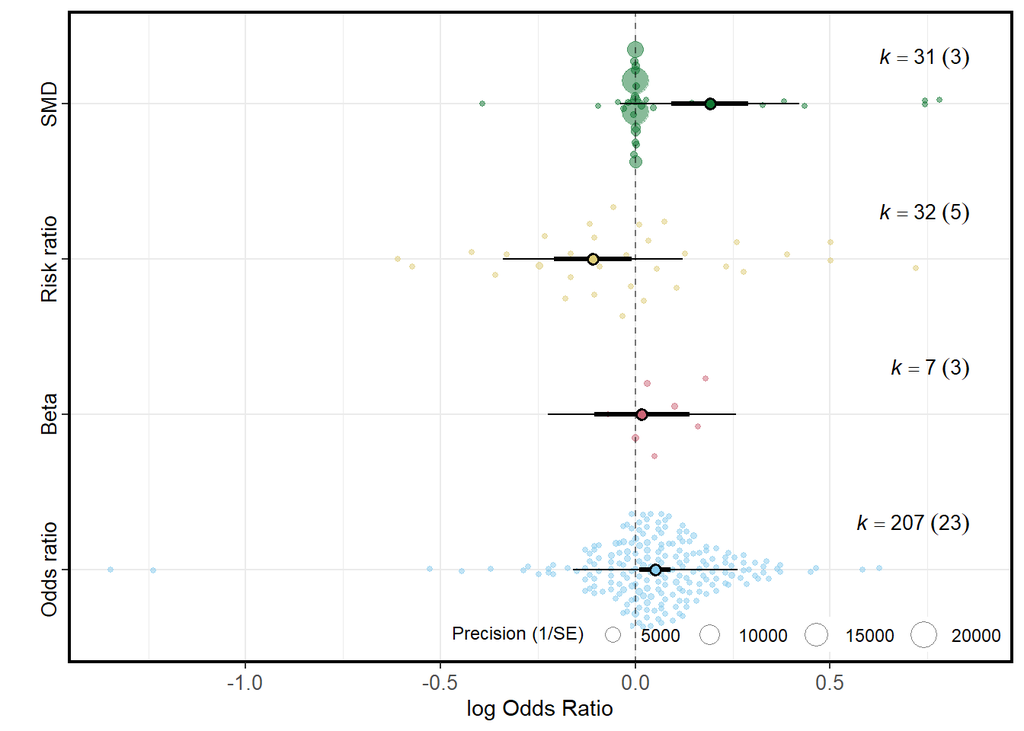

```r
orchard_plot(
  object = mod_test,
  mod = "ma_es_measure",
  group = "ma_id",
  xlab = "log Odds Ratio",
  colour  = FALSE,
  transfm = "none"
) +
  theme(
    panel.border = element_rect(colour = "black", fill = NA, size = 1.3),
    axis.text.x = element_text(size = 10)
  )
```

The models showed that our strategy for transformation of effect size metrics into logOR had a significant impact on the overall result.

```r
ma_e_details_try <- ma_e_details %>%
  filter(ma_es_measure != "SMD (standardized mean difference)")

mod_try <- rma.mv(yi = logOR,
              V = se^2,
              random = list(~1|ma_id,
                            ~1|ma_e_id),
              data = ma_e_details_try)

summary(mod_try)

orchard_plot(
  object = mod_try,
  group = "ma_id",
  xlab = "log Odds Ratio",
  colour  = FALSE,
  transfm = "none"
) +
  theme(
    panel.border = element_rect(colour = "black", fill = NA, size = 1.3),
    axis.text.x = element_text(size = 10)
  )
```

[output not shown]

## Excluding transofrmations

Let’s reduce our data set to original effect sizes on the Odds Ratio or log Odds Ratio metrics.

```r
ma_e_details_no_transf <- ma_e_details %>%
  filter(ma_es_measure %in% c("Odds ratio", "log Odds ratio") )

mod_no_transf <- rma.mv(yi = logOR,
              V = se^2,
              random = list(~1|ma_id,
                            ~1|ma_e_id),
              data = ma_e_details_no_transf)

# Display model results
summary(mod_no_transf)
```

```
##
## Multivariate Meta-Analysis Model (k = 207; method: REML)
##
##    logLik   Deviance        AIC        BIC       AICc
##  106.8061  -213.6122  -207.6122  -197.6286  -207.4934
##
## Variance Components:
##
##             estim    sqrt  nlvls  fixed   factor
## sigma^2.1  0.0017  0.0410     23     no    ma_id
## sigma^2.2  0.0065  0.0804    207     no  ma_e_id
##
## Test for Heterogeneity:
## Q(df = 206) = 609.6795, p-val < .0001
##
## Model Results:
##
## estimate      se    zval    pval   ci.lb   ci.ub
##   0.0600  0.0129  4.6394  <.0001  0.0346  0.0853  ***
##
## ---
## Signif. codes:  0 '***' 0.001 '**' 0.01 '*' 0.05 '.' 0.1 ' ' 1
```

```r
# I²
i2_results_no_transf <- i2_ml(mod_no_transf)
print(i2_results_no_transf)
```

```
##   I2_Total   I2_ma_id I2_ma_e_id
##   83.93146   17.33652   66.59494
```

```r
# Print I² values
cat("I² (between studies):", round(i2_results_no_transf["I2_ma_id"], 1), "%\n")
```

```
## I² (between studies): 17.3 %
```

```r
cat("I² (within studies):", round(i2_results_no_transf["I2_ma_e_id"], 1), "%\n")
```

```
## I² (within studies): 66.6 %
```

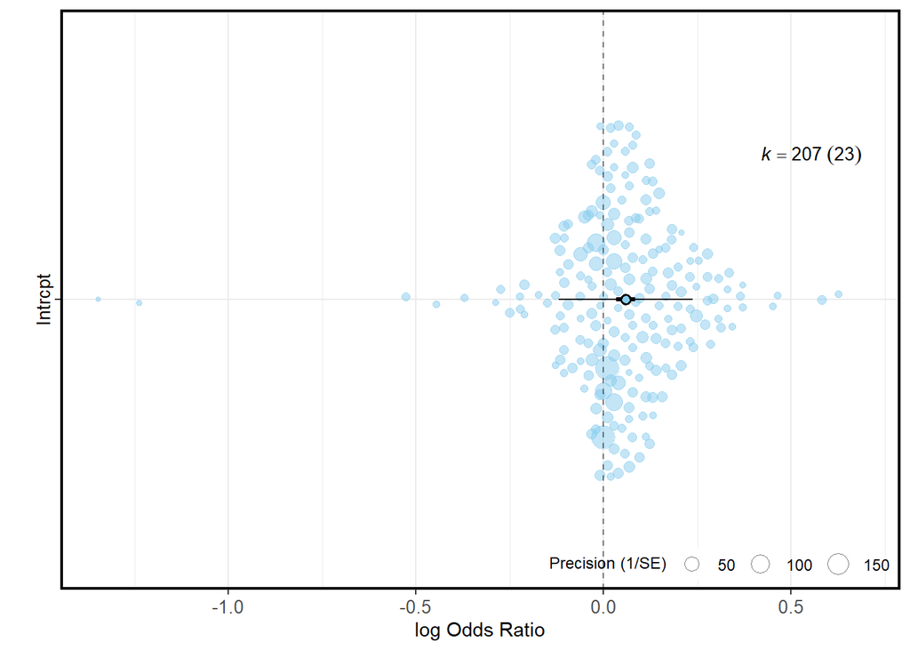

```r
orchard_plot_no_transf <- orchard_plot(
  object = mod_no_transf,
  group = "ma_id",
  xlab = "log Odds Ratio",
  transfm = "none"
) +
  theme(
    panel.border = element_rect(colour = "black", fill = NA, size = 1.3),
    axis.text.x = element_text(size = 10)
  )

# Display the plot
print(orchard_plot_no_transf)
```

# Second Research Question

## Chemicals

Is there any difference in the significance and strength of the association with adverse health outcomes among individual PFAS? YES - p-val < .0001

```r
ma_e_details_no_transf$chemical_id <- as.factor(ma_e_details_no_transf$chemical_id)

mod2 <- rma.mv(yi = logOR,
              V = se^2,
              random = list(~1|ma_id,
                            ~1|ma_e_id),
              mods = ~ chemical_id -1,
              data = ma_e_details_no_transf)

# Display model results
summary(mod2)
```

```
##
## Multivariate Meta-Analysis Model (k = 207; method: REML)
##
##    logLik   Deviance        AIC        BIC       AICc
##  108.9873  -217.9746  -187.9746  -138.9567  -185.2780
##
## Variance Components:
##
##             estim    sqrt  nlvls  fixed   factor
## sigma^2.1  0.0026  0.0511     23     no    ma_id
## sigma^2.2  0.0048  0.0690    207     no  ma_e_id
##
## Test for Residual Heterogeneity:
## QE(df = 194) = 544.1248, p-val < .0001
##
## Test of Moderators (coefficients 1:13):
## QM(df = 13) = 47.1790, p-val < .0001
##
## Model Results:
##
##                        estimate      se     zval    pval    ci.lb   ci.ub
## chemical_idPFAS          0.0540  0.0379   1.4244  0.1543  -0.0203  0.1284
## chemical_idPFBS          0.2947  0.1024   2.8766  0.0040   0.0939  0.4955   **
## chemical_idPFDA          0.0158  0.0319   0.4943  0.6211  -0.0467  0.0783
## chemical_idPFDoDA        0.0317  0.0820   0.3868  0.6989  -0.1290  0.1925
## chemical_idPFHpA        -0.0256  0.0589  -0.4353  0.6633  -0.1411  0.0898
## chemical_idPFHpS        -0.0117  0.2481  -0.0471  0.9624  -0.4979  0.4745
## chemical_idPFHxS         0.0549  0.0207   2.6478  0.0081   0.0143  0.0955   **
## chemical_idPFNA          0.0413  0.0231   1.7854  0.0742  -0.0040  0.0866    .
## chemical_idPFOA          0.0820  0.0204   4.0198  <.0001   0.0420  0.1220  ***
## chemical_idPFOS          0.0877  0.0198   4.4335  <.0001   0.0489  0.1265  ***
## chemical_idPFOSA-AcOH    0.0478  0.1156   0.4131  0.6796  -0.1788  0.2743
## chemical_idPFTrDA       -1.3296  0.9397  -1.4149  0.1571  -3.1713  0.5122
## chemical_idPFUnDA       -0.0741  0.0414  -1.7887  0.0737  -0.1553  0.0071    .
##
## ---
## Signif. codes:  0 '***' 0.001 '**' 0.01 '*' 0.05 '.' 0.1 ' ' 1
```

```r
i2_ml(mod2)
```

```
##   I2_Total   I2_ma_id I2_ma_e_id
##   82.52627   29.24900   53.27727
```

## Health outcome class

Is there any difference in the significance and strength of the association with PFAS exposure among individual classes (lower level) of adverse health outcomes? YES - p-val = 0.0005

What classes (lower level) of adverse health outcomes are significantly associated with PFAS exposure? Hypertensive diseases: p-val = 0.0024 Metabolic disorders: p-val = 0.0055 Oedema, proteinuria, or hypertensive disorders in pregnancy, childbirth, or the puerperium: p-val = 0.0020 Osteopathies or chondropathies: p-val = 0.0410

```r
ma_e_details_no_transf$health_outcome_class <- as.factor(ma_e_details_no_transf$health_outcome_class)
#ma_e_details_no_transf$health_outcome_class <- relevel(ma_e_details_no_transf$health_outcome_class, ref = "Hypertensive diseases")

mod3 <- rma.mv(yi = logOR,
              V = se^2,
              random = list(~1|ma_id,
                            ~1|ma_e_id),
              mods = ~ health_outcome_class -1,
              data = ma_e_details_no_transf)

# Display model results
summary(mod3)
```

```
##
## Multivariate Meta-Analysis Model (k = 207; method: REML)
##
##    logLik   Deviance        AIC        BIC       AICc
##   98.4445  -196.8889  -158.8889   -97.1955  -154.4183
##
## Variance Components:
##
##             estim    sqrt  nlvls  fixed   factor
## sigma^2.1  0.0009  0.0307     23     no    ma_id
## sigma^2.2  0.0069  0.0833    207     no  ma_e_id
##
## Test for Residual Heterogeneity:
## QE(df = 190) = 463.9389, p-val < .0001
##
## Test of Moderators (coefficients 1:17):
## QM(df = 17) = 43.0321, p-val = 0.0005
##
## Model Results:
##
##                                                                                                                         estimate
## health_outcome_classAbortive outcome of pregnancy                                                                         0.0710
## health_outcome_classCertain lower respiratory tract diseases                                                              0.0479
## health_outcome_classCertain specified maternal disorders predominantly related to pregnancy                               0.0513
## health_outcome_classDiseases of the female genital system                                                                -0.0039
## health_outcome_classDisorders of newborn related to length of gestation or fetal growth                                   0.0473
## health_outcome_classEndocrine diseases                                                                                    0.0078
## health_outcome_classFetus or newborn affected by maternal factors or by complications of pregnancy, labour or delivery    0.0744
## health_outcome_classHypertensive diseases                                                                                 0.0858
## health_outcome_classInflammatory dermatoses                                                                               0.0121
## health_outcome_classMalignant neoplasms                                                                                   0.0503
## health_outcome_classMetabolic disorders                                                                                   0.1741
## health_outcome_classNeurodevelopmental disorders                                                                         -0.0091
## health_outcome_classNutritional disorders                                                                                 0.3293
## health_outcome_classOedema, proteinuria, or hypertensive disorders in pregnancy, childbirth, or the puerperium            0.0909
## health_outcome_classOsteopathies or chondropathies                                                                        0.1523
## health_outcome_classSymptoms, signs or clinical findings of the respiratory system                                       -0.0277
## health_outcome_classUpper respiratory tract disorders                                                                     0.0890
##                                                                                                                             se
## health_outcome_classAbortive outcome of pregnancy                                                                       0.0426
```

[output cut: 94 more lines]

```
## health_outcome_classEndocrine diseases
## health_outcome_classFetus or newborn affected by maternal factors or by complications of pregnancy, labour or delivery
## health_outcome_classHypertensive diseases                                                                               **
## health_outcome_classInflammatory dermatoses
## health_outcome_classMalignant neoplasms                                                                                  .
## health_outcome_classMetabolic disorders                                                                                 **
## health_outcome_classNeurodevelopmental disorders
## health_outcome_classNutritional disorders
## health_outcome_classOedema, proteinuria, or hypertensive disorders in pregnancy, childbirth, or the puerperium          **
## health_outcome_classOsteopathies or chondropathies                                                                       *
## health_outcome_classSymptoms, signs or clinical findings of the respiratory system
## health_outcome_classUpper respiratory tract disorders
##
## ---
## Signif. codes:  0 '***' 0.001 '**' 0.01 '*' 0.05 '.' 0.1 ' ' 1
```

## Healtch outcome group

Is there any difference in the significance and strength of the association with PFAS exposure among individual groups (higher level) of adverse health outcomes? YES - p-val = 0.0014

```r
ma_e_details_no_transf$health_outcome_group <- as.factor(ma_e_details_no_transf$health_outcome_group)

mod4 <- rma.mv(yi = logOR,
              V = se^2,
              random = list(~1|ma_id,
                            ~1|ma_e_id),
              mods = ~ health_outcome_group -1,
              data = ma_e_details_no_transf)

# Display model results
summary(mod4)
```

```
##
## Multivariate Meta-Analysis Model (k = 207; method: REML)
##
##    logLik   Deviance        AIC        BIC       AICc
##  101.7884  -203.5768  -177.5768  -134.9613  -175.5768
##
## Variance Components:
##
##             estim    sqrt  nlvls  fixed   factor
## sigma^2.1  0.0017  0.0413     23     no    ma_id
## sigma^2.2  0.0065  0.0809    207     no  ma_e_id
##
## Test for Residual Heterogeneity:
## QE(df = 196) = 518.3876, p-val < .0001
##
## Test of Moderators (coefficients 1:11):
## QM(df = 11) = 30.3692, p-val = 0.0014
##
## Model Results:
##
##                                                                                     estimate
## health_outcome_groupCertain conditions originating in the perinatal period            0.0565
## health_outcome_groupDiseases of the circulatory system                                0.0860
## health_outcome_groupDiseases of the genitourinary system                             -0.0056
## health_outcome_groupDiseases of the musculoskeletal system or connective tissue       0.1523
## health_outcome_groupDiseases of the respiratory system                                0.0697
## health_outcome_groupDiseases of the skin                                              0.0113
## health_outcome_groupEndocrine, nutritional or metabolic diseases                      0.0981
## health_outcome_groupMental, behavioural or neurodevelopmental disorders              -0.0057
## health_outcome_groupNeoplasms                                                         0.0517
## health_outcome_groupPregnancy, childbirth or the puerperium                           0.0723
## health_outcome_groupSymptoms, signs or clinical findings, not elsewhere classified   -0.0276
##                                                                                         se
## health_outcome_groupCertain conditions originating in the perinatal period          0.0302
## health_outcome_groupDiseases of the circulatory system                              0.0324
## health_outcome_groupDiseases of the genitourinary system                            0.0686
## health_outcome_groupDiseases of the musculoskeletal system or connective tissue     0.0788
## health_outcome_groupDiseases of the respiratory system                              0.0627
## health_outcome_groupDiseases of the skin                                            0.0587
## health_outcome_groupEndocrine, nutritional or metabolic diseases                    0.0473
```

[output cut: 52 more lines]

```
##
## health_outcome_groupCertain conditions originating in the perinatal period           .
## health_outcome_groupDiseases of the circulatory system                              **
## health_outcome_groupDiseases of the genitourinary system
## health_outcome_groupDiseases of the musculoskeletal system or connective tissue      .
## health_outcome_groupDiseases of the respiratory system
## health_outcome_groupDiseases of the skin
## health_outcome_groupEndocrine, nutritional or metabolic diseases                     *
## health_outcome_groupMental, behavioural or neurodevelopmental disorders
## health_outcome_groupNeoplasms
## health_outcome_groupPregnancy, childbirth or the puerperium                         **
## health_outcome_groupSymptoms, signs or clinical findings, not elsewhere classified
##
## ---
## Signif. codes:  0 '***' 0.001 '**' 0.01 '*' 0.05 '.' 0.1 ' ' 1
```

# Third Research Question

## Chemicals

```r
mod_sub <- rma.mv(yi = logOR,
                  V = se^2,
                  mods = ~ chemical_id -1,
                   random = list(~1|ma_id,
                                 ~1|ma_e_id,
                                 ~ chemical_id|health_outcome_group),
                   test = "t", #to conunteract potential small sample size
                   sparse = T,
                   data = ma_e_details_no_transf,
                   control = list(iter.max = 1000,
                                  rel.tol = 1e-8))

# Display model results
summary(mod_sub)
```

```
##
## Multivariate Meta-Analysis Model (k = 207; method: REML)
##
##    logLik   Deviance        AIC        BIC       AICc
##  111.4779  -222.9558  -188.9558  -133.4022  -185.4785
##
## Variance Components:
##
##             estim    sqrt  nlvls  fixed   factor
## sigma^2.1  0.0028  0.0533     23     no    ma_id
## sigma^2.2  0.0036  0.0596    207     no  ma_e_id
##
## outer factor: health_outcome_group (nlvls = 11)
## inner factor: chemical_id          (nlvls = 13)
##
##              estim    sqrt  fixed
## tau^2       0.0006  0.0245     no
## rho        -0.9464             no
##
## Test for Residual Heterogeneity:
## QE(df = 194) = 544.1248, p-val < .0001
##
## Test of Moderators (coefficients 1:13):
## F(df1 = 13, df2 = 194) = 12769262.8614, p-val < .0001
##
## Model Results:
##
##                        estimate      se     tval   df    pval    ci.lb   ci.ub
## chemical_idPFAS          0.0548  0.0408   1.3433  194  0.1807  -0.0257  0.1353
## chemical_idPFBS          0.3160  0.0892   3.5426  194  0.0005   0.1401  0.4919
## chemical_idPFDA          0.0202  0.0334   0.6037  194  0.5468  -0.0457  0.0861
## chemical_idPFDoDA        0.0382  0.0780   0.4896  194  0.6250  -0.1157  0.1921
## chemical_idPFHpA        -0.0235  0.0593  -0.3962  194  0.6924  -0.1405  0.0935
## chemical_idPFHpS        -0.0211  0.2439  -0.0867  194  0.9310  -0.5022  0.4599
## chemical_idPFHxS         0.0636  0.0204   3.1207  194  0.0021   0.0234  0.1039
## chemical_idPFNA          0.0439  0.0234   1.8711  194  0.0628  -0.0024  0.0901
## chemical_idPFOA          0.0837  0.0218   3.8448  194  0.0002   0.0408  0.1266
## chemical_idPFOS          0.0902  0.0201   4.4889  194  <.0001   0.0506  0.1299
## chemical_idPFOSA-AcOH    0.0740  0.0958   0.7726  194  0.4407  -0.1149  0.2629
## chemical_idPFTrDA       -1.3284  0.9395  -1.4140  194  0.1590  -3.1814  0.5245
## chemical_idPFUnDA       -0.0609  0.0394  -1.5456  194  0.1238  -0.1385  0.0168
##
## chemical_idPFAS
## chemical_idPFBS        ***
## chemical_idPFDA
## chemical_idPFDoDA
## chemical_idPFHpA
## chemical_idPFHpS
## chemical_idPFHxS        **
## chemical_idPFNA          .
## chemical_idPFOA        ***
## chemical_idPFOS        ***
## chemical_idPFOSA-AcOH
## chemical_idPFTrDA
## chemical_idPFUnDA
##
## ---
## Signif. codes:  0 '***' 0.001 '**' 0.01 '*' 0.05 '.' 0.1 ' ' 1
```

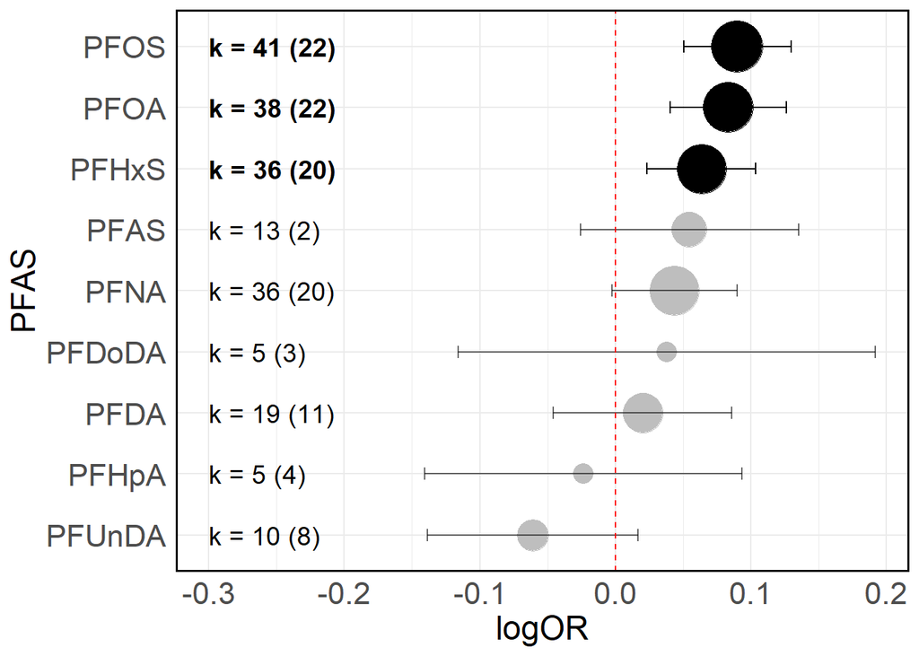

```r
k_n_data <- ma_e_details_no_transf %>%
  group_by(chemical_id) %>%
  arrange(chemical_id) %>%
  summarise(k = n(), n = length(unique(ma_id)))

res_tab1 <- broom::tidy(mod_sub)
res_tab1$ci.lb <- mod_sub$ci.lb
res_tab1$ci.ub <- mod_sub$ci.ub
res_tab1$pval <-mod_sub$pval
res_tab1 <- res_tab1 %>%
  mutate(
    chemical_id = str_remove(term, "^chemical_id"),  # Remove 'Pchemical_id: ' prefix
  ) %>%
  arrange(chemical_id)

res_tab1 <- res_tab1 %>%
  mutate(k = k_n_data$k) %>%
  mutate(n = k_n_data$n)

# Prepare the data for plotting and order chemical_id by estimate value
plot_data1 <- res_tab1 %>%
  as.data.frame() %>%
  filter(k > 1) %>%
  arrange(estimate)

# Create the flipped forest plot
forest_plot1 <- ggplot(plot_data1, aes(y = reorder(chemical_id, estimate), x = estimate)) +
  geom_point(aes(size = k),  # Make point size proportional to k
             color = ifelse(plot_data1$pval > 0.05, "grey", "black"),  # You can change the color if desired
             alpha = 1) +  # Add transparency for better visibility
  scale_size(range = c(5, 13)) + # Set minimum size to 3 and maximum to 6
  geom_errorbarh(aes(xmin = ci.lb, xmax = ci.ub),
                 height = 0.2,
                 alpha = ifelse(plot_data1$pval > 0.05, 0.6, 1)) +  # Horizontal error bars
  geom_vline(xintercept = 0, linetype = "dashed", color = "red") +  # Reference line at 1
  geom_text(aes(label = paste0("k = ", k, " (", n, ")"), x = - 0.3),
            hjust = 0, size = 5, # Add k values as text next to the points
            fontface = ifelse(plot_data1$pval < 0.05, "bold", "plain")) +  # Access pval outside aes()
  # Add "*" next to PFUnDA and PFNA
  # geom_text(data = subset(plot_data1, PFAS_ID %in% c("PFUnDA", "PFNA", "PFTrDA", "PFDoDA", "FOSA", "PFHxS", "PFDS", "PFTeDA", "PFOA", "PFBA", "PFPeA", "PFHpA", "PFBS", "PFHxA")),
  #           aes(x = -0.21, label = "*"), size = 9, color = "black") +
  # geom_text(data = subset(plot_data1, PFAS_ID %in% c("PFUnDA", "PFNA", "PFTrDA", "PFDoDA", "FOSA", "PFHxS", "PFDS", "PFTeDA", "PFOA", "PFBA", "PFPeA", "PFHpA", "PFBS", "PFHxA")),
  #           aes(x = ci.lb, label = "*"),
  #           hjust = 1.2, vjust = 0.7, size = 6, color = "black") +
  xlab("logOR") +
  ylab("PFAS") +
  #ggtitle("B") +
  theme_minimal() +  # Use a minimal theme
  theme(legend.position = "none",
        panel.border = element_rect(colour = "black", fill = NA, size = 1),
         plot.title = element_text(face = "bold", size = 18),
       legend.title = element_text(size = 16),
        legend.text = element_text(size = 15),
        axis.title.x = element_text(size = 18),
        axis.title.y = element_text(size = 18),
        axis.text.y = element_text(size = 17),
       axis.text.x = element_text(size = 17)) #+
   #scale_x_break(c(4, 6)) +
   #scale_x_continuous(breaks = seq(0, 4, by = 1), limits = c(-0.21, 4))

forest_plot1
```

## Health outcomes (groups)

```r
mod_sub2 <- rma.mv(yi = logOR,
                  V = se^2,
                  mods = ~ health_outcome_group -1,
                   random = list(~1|ma_id,
                                 ~1|ma_e_id,
                                 ~ health_outcome_group|chemical_id),
                   test = "t", #to conunteract potential small sample size
                   sparse = T,
                   data = ma_e_details_no_transf,
                   control = list(iter.max = 1000,
                                  rel.tol = 1e-8))

# Display model results
summary(mod_sub2)
```

```
##
## Multivariate Meta-Analysis Model (k = 207; method: REML)
##
##    logLik   Deviance        AIC        BIC       AICc
##  105.1441  -210.2882  -180.2882  -131.1164  -177.6215
##
## Variance Components:
##
##             estim    sqrt  nlvls  fixed   factor
## sigma^2.1  0.0024  0.0494     23     no    ma_id
## sigma^2.2  0.0039  0.0625    207     no  ma_e_id
##
## outer factor: chemical_id          (nlvls = 13)
## inner factor: health_outcome_group (nlvls = 11)
##
##             estim    sqrt  fixed
## tau^2      0.0028  0.0530     no
## rho        0.4469             no
##
## Test for Residual Heterogeneity:
## QE(df = 196) = 518.3876, p-val < .0001
##
## Test of Moderators (coefficients 1:11):
## F(df1 = 11, df2 = 196) = 1.2743, p-val = 0.2416
##
## Model Results:
##
##                                                                                     estimate
## health_outcome_groupCertain conditions originating in the perinatal period            0.0506
## health_outcome_groupDiseases of the circulatory system                                0.0717
## health_outcome_groupDiseases of the genitourinary system                             -0.0493
## health_outcome_groupDiseases of the musculoskeletal system or connective tissue       0.1373
## health_outcome_groupDiseases of the respiratory system                                0.0603
## health_outcome_groupDiseases of the skin                                             -0.0050
## health_outcome_groupEndocrine, nutritional or metabolic diseases                      0.0847
## health_outcome_groupMental, behavioural or neurodevelopmental disorders              -0.0168
## health_outcome_groupNeoplasms                                                         0.0444
## health_outcome_groupPregnancy, childbirth or the puerperium                           0.0569
## health_outcome_groupSymptoms, signs or clinical findings, not elsewhere classified   -0.0370
##                                                                                         se
```

[output cut: 71 more lines]

```
##
## health_outcome_groupCertain conditions originating in the perinatal period
## health_outcome_groupDiseases of the circulatory system                              .
## health_outcome_groupDiseases of the genitourinary system
## health_outcome_groupDiseases of the musculoskeletal system or connective tissue
## health_outcome_groupDiseases of the respiratory system
## health_outcome_groupDiseases of the skin
## health_outcome_groupEndocrine, nutritional or metabolic diseases
## health_outcome_groupMental, behavioural or neurodevelopmental disorders
## health_outcome_groupNeoplasms
## health_outcome_groupPregnancy, childbirth or the puerperium                         .
## health_outcome_groupSymptoms, signs or clinical findings, not elsewhere classified
##
## ---
## Signif. codes:  0 '***' 0.001 '**' 0.01 '*' 0.05 '.' 0.1 ' ' 1
```

[figure not shown]

```r
k_n_data <- ma_e_details_no_transf %>%
  group_by(health_outcome_group) %>%
  arrange(health_outcome_group) %>%
  summarise(k = n(), n = length(unique(ma_id)))

res_tab1 <- broom::tidy(mod_sub2)
res_tab1$ci.lb <- mod_sub2$ci.lb
res_tab1$ci.ub <- mod_sub2$ci.ub
res_tab1$pval <-mod_sub2$pval
res_tab1 <- res_tab1 %>%
  mutate(
    health_outcome_group = str_remove(term, "^health_outcome_group"),  # Remove 'Pchemical_id: ' prefix
  ) %>%
  arrange(health_outcome_group)

res_tab1 <- res_tab1 %>%
  mutate(k = k_n_data$k) %>%
  mutate(n = k_n_data$n)

# Prepare the data for plotting and order health_outcome_group by estimate value
plot_data1 <- res_tab1 %>%
  as.data.frame() %>%
  filter(k > 1) %>%
  arrange(estimate)

# Create the flipped forest plot
forest_plot2 <- ggplot(plot_data1, aes(y = reorder(health_outcome_group, estimate), x = estimate)) +
  geom_point(aes(size = k),  # Make point size proportional to k
             color = ifelse(plot_data1$pval > 0.05, "grey", "black"),  # You can change the color if desired
             alpha = 1) +  # Add transparency for better visibility
  scale_size(range = c(5, 13)) + # Set minimum size to 3 and maximum to 6
  geom_errorbarh(aes(xmin = ci.lb, xmax = ci.ub),
                 height = 0.2,
                 alpha = ifelse(plot_data1$pval > 0.05, 0.6, 1)) +  # Horizontal error bars
  geom_vline(xintercept = 0, linetype = "dashed", color = "red") +  # Reference line at 1
  geom_text(aes(label = paste0("k = ", k, " (", n, ")"), x = - 0.3),
            hjust = 0, size = 5, # Add k values as text next to the points
            fontface = ifelse(plot_data1$pval < 0.05, "bold", "plain")) +  # Access pval outside aes()
  # Add "*" next to PFUnDA and PFNA
  # geom_text(data = subset(plot_data1, PFAS_ID %in% c("PFUnDA", "PFNA", "PFTrDA", "PFDoDA", "FOSA", "PFHxS", "PFDS", "PFTeDA", "PFOA", "PFBA", "PFPeA", "PFHpA", "PFBS", "PFHxA")),
  #           aes(x = -0.21, label = "*"), size = 9, color = "black") +
  # geom_text(data = subset(plot_data1, PFAS_ID %in% c("PFUnDA", "PFNA", "PFTrDA", "PFDoDA", "FOSA", "PFHxS", "PFDS", "PFTeDA", "PFOA", "PFBA", "PFPeA", "PFHpA", "PFBS", "PFHxA")),
  #           aes(x = ci.lb, label = "*"),
  #           hjust = 1.2, vjust = 0.7, size = 6, color = "black") +
  xlab("logOR") +
  ylab("Health Outcome Group") +
  ggtitle("A") +
  theme_minimal() +  # Use a minimal theme
  theme(legend.position = "none",
        panel.border = element_rect(colour = "black", fill = NA, size = 1),
         plot.title = element_text(face = "bold", size = 18),
       legend.title = element_text(size = 16),
        legend.text = element_text(size = 15),
        axis.title.x = element_text(size = 18),
        axis.title.y = element_text(size = 18),
        axis.text.y = element_text(size = 17),
       axis.text.x = element_text(size = 17)) #+
   #scale_x_break(c(4, 6)) +
   #scale_x_continuous(breaks = seq(0, 4, by = 1), limits = c(-0.21, 4))

forest_plot2
```

## Health outcomes (classes)

```r
mod_sub3 <- rma.mv(yi = logOR,
                  V = se^2,
                  mods = ~ health_outcome_class -1,
                   random = list(~1|ma_id,
                                 ~1|ma_e_id,
                                 ~ health_outcome_class|chemical_id),
                   test = "t", #to conunteract potential small sample size
                   sparse = T,
                   data = ma_e_details_no_transf,
                   control = list(iter.max = 1000,
                                  rel.tol = 1e-8))

# Display model results
summary(mod_sub3)
```

```
##
## Multivariate Meta-Analysis Model (k = 207; method: REML)
##
##    logLik   Deviance        AIC        BIC       AICc
##  103.3651  -206.7303  -164.7303   -96.5428  -159.2303
##
## Variance Components:
##
##             estim    sqrt  nlvls  fixed   factor
## sigma^2.1  0.0010  0.0312     23     no    ma_id
## sigma^2.2  0.0036  0.0598    207     no  ma_e_id
##
## outer factor: chemical_id          (nlvls = 13)
## inner factor: health_outcome_class (nlvls = 17)
##
##             estim    sqrt  fixed
## tau^2      0.0038  0.0620     no
## rho        0.3477             no
##
## Test for Residual Heterogeneity:
## QE(df = 190) = 463.9389, p-val < .0001
##
## Test of Moderators (coefficients 1:17):
## F(df1 = 17, df2 = 190) = 1.3765, p-val = 0.1517
##
## Model Results:
##
##                                                                                                                         estimate
## health_outcome_classAbortive outcome of pregnancy                                                                         0.0549
## health_outcome_classCertain lower respiratory tract diseases                                                              0.0381
## health_outcome_classCertain specified maternal disorders predominantly related to pregnancy                               0.0426
## health_outcome_classDiseases of the female genital system                                                                -0.0513
## health_outcome_classDisorders of newborn related to length of gestation or fetal growth                                   0.0301
## health_outcome_classEndocrine diseases                                                                                   -0.0095
## health_outcome_classFetus or newborn affected by maternal factors or by complications of pregnancy, labour or delivery    0.0693
## health_outcome_classHypertensive diseases                                                                                 0.0684
## health_outcome_classInflammatory dermatoses                                                                              -0.0079
## health_outcome_classMalignant neoplasms                                                                                   0.0450
## health_outcome_classMetabolic disorders                                                                                   0.1682
## health_outcome_classNeurodevelopmental disorders                                                                         -0.0234
```

[output cut: 119 more lines]

```
## health_outcome_classEndocrine diseases
## health_outcome_classFetus or newborn affected by maternal factors or by complications of pregnancy, labour or delivery
## health_outcome_classHypertensive diseases                                                                                .
## health_outcome_classInflammatory dermatoses
## health_outcome_classMalignant neoplasms
## health_outcome_classMetabolic disorders                                                                                 **
## health_outcome_classNeurodevelopmental disorders
## health_outcome_classNutritional disorders
## health_outcome_classOedema, proteinuria, or hypertensive disorders in pregnancy, childbirth, or the puerperium           *
## health_outcome_classOsteopathies or chondropathies                                                                       .
## health_outcome_classSymptoms, signs or clinical findings of the respiratory system
## health_outcome_classUpper respiratory tract disorders
##
## ---
## Signif. codes:  0 '***' 0.001 '**' 0.01 '*' 0.05 '.' 0.1 ' ' 1
```

[figure not shown]

```r
k_n_data <- ma_e_details_no_transf %>%
  group_by(health_outcome_class) %>%
  arrange(health_outcome_class) %>%
  summarise(k = n(), n = length(unique(ma_id)))

res_tab1 <- broom::tidy(mod_sub3)
res_tab1$ci.lb <- mod_sub3$ci.lb
res_tab1$ci.ub <- mod_sub3$ci.ub
res_tab1$pval <-mod_sub3$pval
res_tab1 <- res_tab1 %>%
  mutate(
    health_outcome_class = str_remove(term, "^health_outcome_class"),  # Remove 'Pchemical_id: ' prefix
  ) %>%
  arrange(health_outcome_class)

res_tab1 <- res_tab1 %>%
  mutate(k = k_n_data$k) %>%
  mutate(n = k_n_data$n)

# Prepare the data for plotting and order health_outcome_class by estimate value
plot_data1 <- res_tab1 %>%
  as.data.frame() %>%
  filter(k > 1) %>%
  arrange(estimate)

# Create the flipped forest plot
forest_plot2 <- ggplot(plot_data1, aes(y = reorder(health_outcome_class, estimate), x = estimate)) +
  geom_point(aes(size = k),  # Make point size proportional to k
             color = ifelse(plot_data1$pval > 0.05, "grey", "black"),  # You can change the color if desired
             alpha = 1) +  # Add transparency for better visibility
  scale_size(range = c(5, 13)) + # Set minimum size to 3 and maximum to 6
  geom_errorbarh(aes(xmin = ci.lb, xmax = ci.ub),
                 height = 0.2,
                 alpha = ifelse(plot_data1$pval > 0.05, 0.6, 1)) +  # Horizontal error bars
  geom_vline(xintercept = 0, linetype = "dashed", color = "red") +  # Reference line at 1
  geom_text(aes(label = paste0("k = ", k, " (", n, ")"), x = - 0.3),
            hjust = 0, size = 5, # Add k values as text next to the points
            fontface = ifelse(plot_data1$pval < 0.05, "bold", "plain")) +  # Access pval outside aes()
  # Add "*" next to PFUnDA and PFNA
  # geom_text(data = subset(plot_data1, PFAS_ID %in% c("PFUnDA", "PFNA", "PFTrDA", "PFDoDA", "FOSA", "PFHxS", "PFDS", "PFTeDA", "PFOA", "PFBA", "PFPeA", "PFHpA", "PFBS", "PFHxA")),
  #           aes(x = -0.21, label = "*"), size = 9, color = "black") +
  # geom_text(data = subset(plot_data1, PFAS_ID %in% c("PFUnDA", "PFNA", "PFTrDA", "PFDoDA", "FOSA", "PFHxS", "PFDS", "PFTeDA", "PFOA", "PFBA", "PFPeA", "PFHpA", "PFBS", "PFHxA")),
  #           aes(x = ci.lb, label = "*"),
  #           hjust = 1.2, vjust = 0.7, size = 6, color = "black") +
  xlab("logOR") +
  ylab("Health Outcome Class") +
  ggtitle("B") +
  theme_minimal() +  # Use a minimal theme
  theme(legend.position = "none",
        panel.border = element_rect(colour = "black", fill = NA, size = 1),
         plot.title = element_text(face = "bold", size = 18),
       legend.title = element_text(size = 16),
        legend.text = element_text(size = 15),
        axis.title.x = element_text(size = 18),
        axis.title.y = element_text(size = 18),
        axis.text.y = element_text(size = 17),
       axis.text.x = element_text(size = 17)) #+
   #scale_x_break(c(4, 6)) +
   #scale_x_continuous(breaks = seq(0, 4, by = 1), limits = c(-0.21, 4))

forest_plot2
```